# Arran

First I need to load up the packages I’ll need

```r
library(sf)
```

```r
library(ggplot2) #development version!
## devtools::install_github("tidyverse/ggplot2")
library(tidyverse)
library(readr)
## Not sure about this bit
library("tidyverse", lib.loc="/Library/Frameworks/R.framework/Versions/3.4/Resources/library")
```

Now I need to import my data In this case ‘Code-Point Open - GB’, already downloaded from https://www.ordnancesurvey.co.uk/opendatadownload/products.html. I’ve already selected the National Grid Reference square I needed and put on the desktop.

```r
## Import data
ka <- read.csv("alldata/ka.csv")
```

Fiddle about with it.

```r
## Print it if you like by inputting "ka".

## Summarise it
summary(ka)
```

```
##     Postcode     Positional_quality_indicator    Eastings
##  KA1 1AD:    1   Min.   :10.00                Min.   :186518
##  KA1 1BA:    1   1st Qu.:10.00                1st Qu.:230354
##  KA1 1BB:    1   Median :10.00                Median :234718
##  KA1 1BD:    1   Mean   :10.07                Mean   :235880
##  KA1 1BE:    1   3rd Qu.:10.00                3rd Qu.:242737
##  KA1 1BG:    1   Max.   :50.00                Max.   :275443
##  (Other):11550
##    Northings         Country_code   NHS_regional_HA_code    NHS_HA_code
##  Min.   :575083   S92000003:11556   Mode:logical         S08000015:11556
##  1st Qu.:622559                     NA's:11556
##  Median :637058
##  Mean   :633124
##  3rd Qu.:642120
##  Max.   :666156
##
##  Admin_county_code Admin_district_code  Admin_ward_code
##  Mode:logical      S12000008:3927      S13003091: 644
##  NA's:11556        S12000021:4076      S13002894: 589
##                    S12000028:3553      S13002892: 539
##                                        S13002898: 534
##                                        S13002899: 507
##                                        S13003039: 502
##                                        (Other)  :8241
```

```r
## Find out classes
sapply(ka,class)
```

```
##                     Postcode Positional_quality_indicator
##                     "factor"                    "integer"
##                     Eastings                    Northings
##                    "integer"                    "integer"
##                 Country_code         NHS_regional_HA_code
##                     "factor"                    "logical"
##                  NHS_HA_code            Admin_county_code
##                     "factor"                    "logical"
##          Admin_district_code              Admin_ward_code
##                     "factor"                     "factor"
```

```r
## Use this bit to check which columns had unique values
## E.g Positional_quality_indicator column
length(unique(ka$Positional_quality_indicator))
```

```
## [1] 3
```

Now I plot the entire grid reference square as co-ordinates.

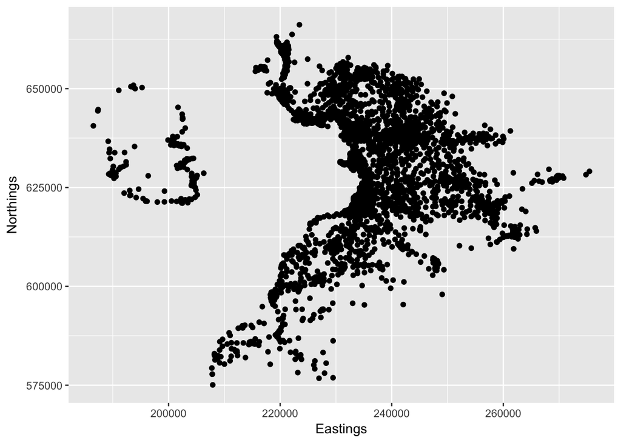

```r
## Plot Postcodes as co-ordinates
ggplot(data = ka) +
  geom_point(mapping = aes(x = Eastings, y = Northings))
```

Now I subselect from the KA data. Initially I had to do this by looking at the data which was organised alphabetically by postcode. Since Arran all begins ‘KA27’ it means I could simply select out the rows containing Arran postcodes together.

```r
## Selecting columns
postcodecoord <- data.frame(ka$Postcode,ka$Eastings,ka$Northings)
## OR
postcodecoord <- ka[,c("Postcode","Eastings","Northings")]

## Selecting rows
Arran <- ka[c(6700:6896),c("Postcode","Eastings","Northings")]
```

Now I plot it. (With a few labels, etc)

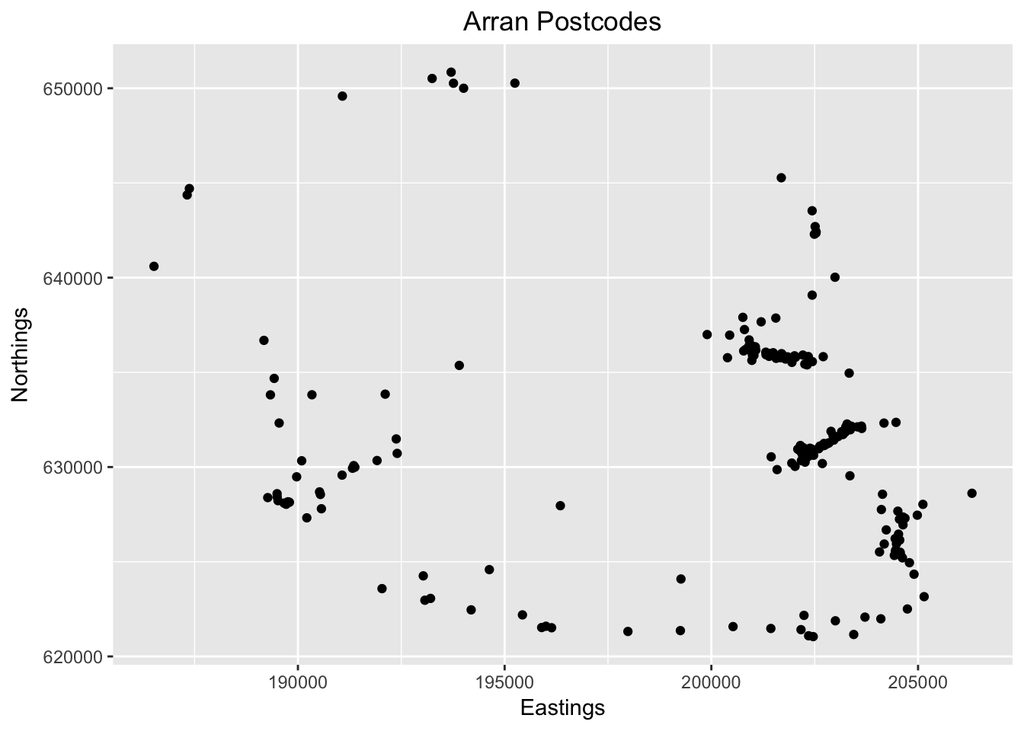

```r
## Neater version
ggplot(data = Arran) +
  geom_point(mapping = aes(x = Eastings, y = Northings)) +
  ggtitle("Arran Postcodes") +
  labs(title = "Arran Postcodes", x = "Eastings", y = "Northings") +
  theme(plot.title = element_text(hjust = 0.5))
```

## –

Now I try something different. I found some new data from somewhere. I import it. I filter for the Arran postcodes using a more clever code then last time.

```r
## Finding the Arran coordinates
library(dplyr)
allcoordinates <- read.csv("alldata/ukpostcodes.csv")
arrancoordinates <- filter(allcoordinates,substr(postcode,1,4)=="KA27")
```

Now I plot that instead.

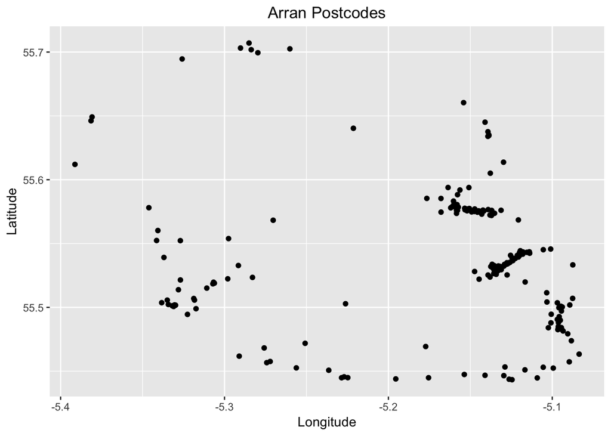

```r
## Plotting the Arran coordinates
ggplot(data = arrancoordinates) +
  geom_point(mapping = aes(x = longitude, y = latitude)) +
  ggtitle("Arran Postcodes") +
  labs(title = "Arran Postcodes", x = "Longitude", y = "Latitude") +
  theme(plot.title = element_text(hjust = 0.5))
```

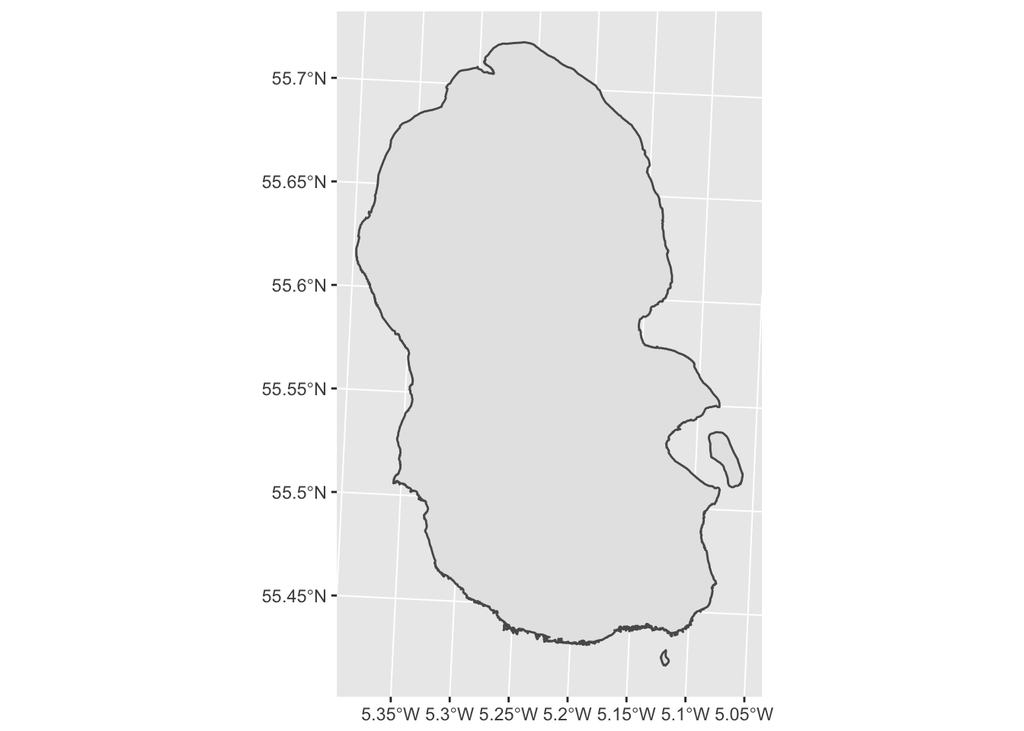

```r
pcs <- read_sf("alldata/Scotland_pcs_2011")

#Print Post codes lists
arransubsect <- filter(pcs,substr(label,1,4)=="KA27")
arransubsect %>%
  ggplot() +
  geom_sf()
```

Now I have to load up a new function.

```r
#Multiplot code
#Multiplot code
#http://www.cookbook-r.com/Graphs/Multiple_graphs_on_one_page_(ggplot2)/
# ggplot objects can be passed in ..., or to plotlist (as a list of ggplot objects)
# - cols:   Number of columns in layout
# - layout: A matrix specifying the layout. If present, 'cols' is ignored.
#
# If the layout is something like matrix(c(1,2,3,3), nrow=2, byrow=TRUE),
# then plot 1 will go in the upper left, 2 will go in the upper right, and
# 3 will go all the way across the bottom.
#
multiplot <- function(..., plotlist=NULL, file, cols=1, layout=NULL) {
  library(grid)

  # Make a list from the ... arguments and plotlist
  plots <- c(list(...), plotlist)

  numPlots = length(plots)

  # If layout is NULL, then use 'cols' to determine layout
  if (is.null(layout)) {
    # Make the panel
    # ncol: Number of columns of plots
    # nrow: Number of rows needed, calculated from # of cols
    layout <- matrix(seq(1, cols * ceiling(numPlots/cols)),
                     ncol = cols, nrow = ceiling(numPlots/cols))
  }

  if (numPlots==1) {
    print(plots[[1]])

  } else {
    # Set up the page
    grid.newpage()
    pushViewport(viewport(layout = grid.layout(nrow(layout), ncol(layout))))

    # Make each plot, in the correct location
    for (i in 1:numPlots) {
      # Get the i,j matrix positions of the regions that contain this subplot
      matchidx <- as.data.frame(which(layout == i, arr.ind = TRUE))

      print(plots[[i]], vp = viewport(layout.pos.row = matchidx$row,
                                      layout.pos.col = matchidx$col))
    }
  }
}
```

Then I can load the shape files.

```r
#Import SIMD data from http://www.gov.scot/Topics/Statistics/SIMD
#The "new data zone boundaries with SIMD16 ranks (zipped shapefile)"
#'2011 Data Zone boundaries'

DZBoundaries2016 <- read_sf("./alldata/SG_SIMD_2016")

#https://data.gov.uk/dataset/scottish-index-of-multiple-deprivation-simd-2012
#https://data.gov.uk/dataset/scottish-index-of-multiple-deprivation-simd-2012/resource/d6fa8924-83da-4e80-a560-4ef0477f230b
DZBoundaries2012 <- read_sf("./alldata/SG_SIMD_2012")
DZBoundaries2009 <- read_sf("./alldata/SG_SIMD_2009")
DZBoundaries2006 <- read_sf("./alldata/SG_SIMD_2006")
DZBoundaries2004 <- read_sf("./alldata/SG_SIMD_2004")
```

Then (having already downloaded it), I can load the SIMD data.

```r
#Look at data from 2016
SIMD2016 <-read.csv("./alldata/00505244.csv")
SIMD20162 <-read_sf("./alldata/SG_SIMD_2016")

#Look at data from 2012
SIMD2012 <- readxl::read_excel("./alldata/SIMD2012/00410770.xls")
SIMD20122 <- readxl::read_excel("./alldata/SIMD2012/00416552.xls")

#Look at data from 2009
SIMD2009 <- readxl::read_excel("./alldata/SIMD2009/0096578.xls")
SIMD20092 <- readxl::read_excel("./alldata/SIMD2009/0097806.xls")

#Look at data from 2006
# 2009 data - SIMD2006 <- readxl::read_excel("./alldata/SIMD2006/0096578.xls")
SIMD20062 <- readxl::read_excel("./alldata/SIMD2006/0097880.xls")

#Look at data from 2004
SIMD2004 <- readxl::read_excel("./alldata/SIMD2004/0027003.xls")
```

I have to choose the right columns manually in order to select the Arran data.

```r
#Selecting ArranDZ2016
Arrandz <- c(4672,4666,4669,4671,4667,4668,4670)

#Health domain rank
#2016
arran2016 <- SIMD20162[Arrandz,]

#Find postcode look-up, KA27 postcodes. Find unique DZ. Find row positions.

#Selecting ArranDZ2012
Arrandz2012 <- c(4409,4372,4353,4352,4351,4350,4349)

#2012
arran2012 <- DZBoundaries2012[Arrandz2012,]
#2009
arran2009 <- DZBoundaries2009[Arrandz2012,]
#2006
arran2006 <- DZBoundaries2006[Arrandz2012,]
#2004
arran2004 <- DZBoundaries2004[Arrandz2012,]
```

Now I can plot all the data.

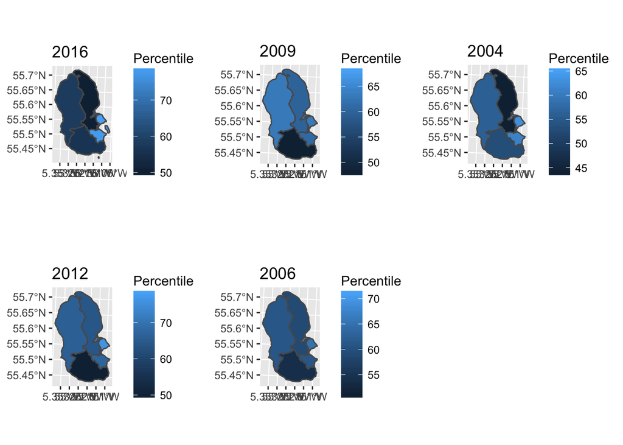

```r
#Plot 2016
p1 <- arran2016 %>%
  ggplot() +
  geom_sf(aes(fill = Percentile)) +
  ggtitle("2016")

#Plot 2012
p2 <- arran2012 %>%
  ggplot() +
  geom_sf(aes(fill = Percentile)) +
  ggtitle("2012")

#Plot 2009
p3 <- arran2009 %>%
  ggplot() +
  geom_sf(aes(fill = Percentile)) +
  ggtitle("2009")

#Plot 2006
p4 <- arran2006 %>%
  ggplot() +
  geom_sf(aes(fill = Percentile)) +
  ggtitle("2006")

#Plot 2004
p5 <- arran2004 %>%
  ggplot() +
  geom_sf(aes(fill = Percentile)) +
  ggtitle("2004")

#Plot 2004-2016 Together
multiplot(p1, p2, p3, p4, p5, cols=3)
```